# Foreigner’s and Crime

Me

# Introduction

## sub heading

An illustration of R Markdown….

What’s the link between foreigners and crime?

## Illustration

To illustrate your story you can include images and hyperlinks (even of [bullies](https://www.bbc.co.uk/news/uk-politics-56125796) who [attack foreigners](https://www.freedomfromtorture.org/news/refugee-rights-are-under-attack-heres-everything-you-need-to-know)

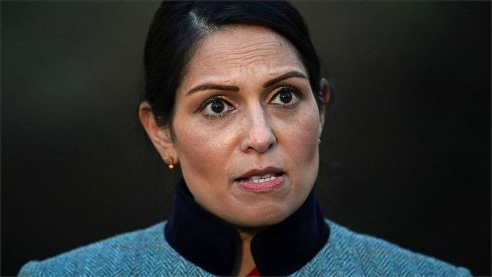

You can also embedd tweets. To illustrate that, let’s hear some remarks from Nigel Farage (The patron saint of the [Farage Garage](https://www.theneweuropean.co.uk/top-stories/faragegarage-trends-on-twitters-over-secret-brexit-lorry-park-1-6743902)):

> [Farage Garage](https://twitter.com/mikegove12/status/1306904285343617025)

# OK some more serious work now

Now let’s load some data. To do that you can include chunks of are code like this:

```r
ff=read.csv("https://www.dropbox.com/s/g1w75gkw7g91zef/foreigners.csv?dl=1")
```

This loads the local authority dataset we have seen before. Note that you can include inline are code as well. For instance: the dataset has 348 observations and contains 5 variables.

As before we can summarise the data:

```r
summary(ff)
```

```
##        X             crimes11          b_migr11          pop11
##  Min.   :  1.00   Min.   :   1134   Min.   : 2.241   Min.   :   2203
##  1st Qu.: 87.75   1st Qu.: 107618   1st Qu.: 4.899   1st Qu.:  94263
##  Median :174.50   Median : 160556   Median : 7.603   Median : 125746
##  Mean   :174.50   Mean   : 236988   Mean   :11.226   Mean   : 161434
##  3rd Qu.:261.25   3rd Qu.: 309377   3rd Qu.:12.382   3rd Qu.: 200247
##  Max.   :348.00   Max.   :1714295   Max.   :55.161   Max.   :1072372
##                   NA's   :24        NA's   :9        NA's   :9
##      area
##  Length:348
##  Class :character
##  Mode  :character
##
##
##
##
```

Note, you might want to see the output of a command in your final document, but you might not want to see the command. Just do it like this:

```
##        X             crimes11          b_migr11          pop11
##  Min.   :  1.00   Min.   :   1134   Min.   : 2.241   Min.   :   2203
##  1st Qu.: 87.75   1st Qu.: 107618   1st Qu.: 4.899   1st Qu.:  94263
##  Median :174.50   Median : 160556   Median : 7.603   Median : 125746
##  Mean   :174.50   Mean   : 236988   Mean   :11.226   Mean   : 161434
##  3rd Qu.:261.25   3rd Qu.: 309377   3rd Qu.:12.382   3rd Qu.: 200247
##  Max.   :348.00   Max.   :1714295   Max.   :55.161   Max.   :1072372
##                   NA's   :24        NA's   :9        NA's   :9
##      area
##  Length:348
##  Class :character
##  Mode  :character
##
##
##
##
```

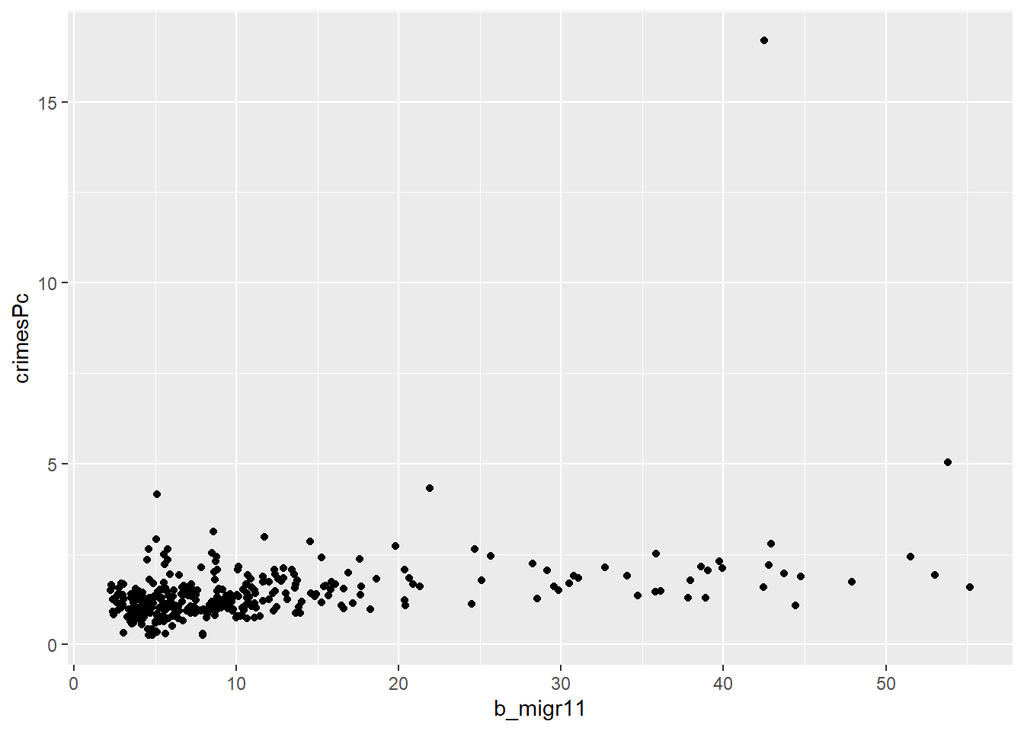

Let’s get rid of outliers…

```r
#ff= filter(ff,crimesPc<15)

ff= ff %>% filter(crimesPc<15)
```

…and do some other stuff to make it look nicer..

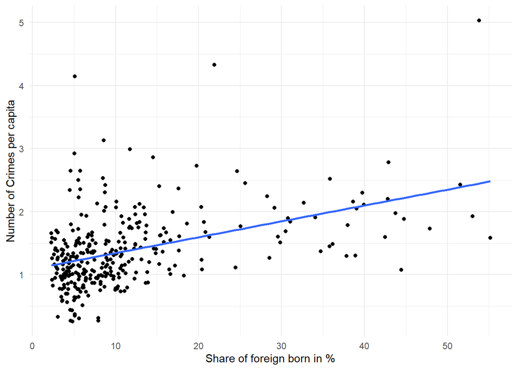

```r
ggplot(ff, aes(y=crimesPc,x=b_migr11)) + geom_point()   +   # Make sure + is on this line so R understands the command is not finished
                   xlab("Share of foreign born in %")   +
                   ylab("Number of Crimes per capita")  +
                   geom_smooth(method = "lm", se = FALSE) +
                   theme_minimal()
```

# Running regressions:

- We said that putting in a trend line in a scatter plot is a way of estimating an econometric model that describes the relationship between the dependent (or outcome) variable on the Y axis and an explanatory variable on the x axis.
- If you want a computer to do this for you (rather take out a ruler and a pen) you need a precise algorithm.
- The most commonly used algorithm for that is called Ordinary Least Squares estimator (OLS).

```r
r1=lm(crimesPc~b_migr11,ff)
# Note we can assign the output of a regression to a variable...

summary(r1)
```

```
##
## Call:
## lm(formula = crimesPc ~ b_migr11, data = ff)
##
## Residuals:
##      Min       1Q   Median       3Q      Max
## -1.13314 -0.33959 -0.06763  0.22302  2.92572
##
## Coefficients:
##             Estimate Std. Error t value Pr(>|t|)
## (Intercept) 1.091273   0.045146   24.17  < 2e-16 ***
## b_migr11    0.025164   0.002922    8.61 3.33e-16 ***
## ---
## Signif. codes:  0 '***' 0.001 '**' 0.01 '*' 0.05 '.' 0.1 ' ' 1
##
## Residual standard error: 0.5482 on 321 degrees of freedom
## Multiple R-squared:  0.1876, Adjusted R-squared:  0.1851
## F-statistic: 74.14 on 1 and 321 DF,  p-value: 3.325e-16
```

```r
# ...and then refer back to this variable in subsequent commands.
# You can check how the output of the lm command looks like by clicking on r1 in the
# variable browser.
```

Note this identifies a linear model of the form
$$Y_i=\beta_0 + \beta_1 \times X_i +\epsilon_i$$
where $Y_i$ is *Crimes per capita* and $X_i$ is the share of foreigners in %. This also shows you how you can integrate formulas in a markdown document and how easily format text to make it italic. More on this under [this](https://rmarkdown.rstudio.com/lesson-8.html) link.
Now this of course is the true model. What we get out of the OLS procedure is an estimate of the above model; i.e.
$$Y_i=\hat{\beta}_0 + \hat{\beta}_1 \times X_i +\hat{\epsilon}_i$$
which given the above R results becomes

$$Y_i=1.091 + 0.025 \times X_i +\hat{\epsilon}_i$$

where we round the results up to 3 digit precision. Check out the code for this in the underlying [Rmd file](https://mondpanther.github.io/datastorieshub/code/FarageGarage.Rmd) as it also shows how you can refer back to a previously caclulated result within an inline formula; i.e. rather than manually typing the value for $\beta_0$ and $\beta_1$ I let R work it out from the `lm` command.

## Implication of OLS

An important implication of the OLS estimator is that it works out the $\beta$ parameters in a way that sets correlation between $\hat{\epsilon}$ and $X$ equal to 0. To check that this is the case we extract the $\epsilon$ from the `r1` variable and add it to our `ff` dataframe.

```r
ff['residuals']=r1$residuals
#Note this is an alternative way of assigning a new variable to a dataframe.
#Alternatively use:
ff=ff %>% mutate(residualsx1=r1$residuals)
```

Note that the correlation is indeed 0:

```r
  ff %>% select(residuals,b_migr11, pop11)  %>% cor(use="complete.obs")
```

```
##              residuals     b_migr11       pop11
## residuals 1.000000e+00 3.310480e-17 0.003356407
## b_migr11  3.310480e-17 1.000000e+00 0.333636733
## pop11     3.356407e-03 3.336367e-01 1.000000000
```

```r
  10^17
```

```
## [1] 1e+17
```

Which we can also see in a scatterplot:

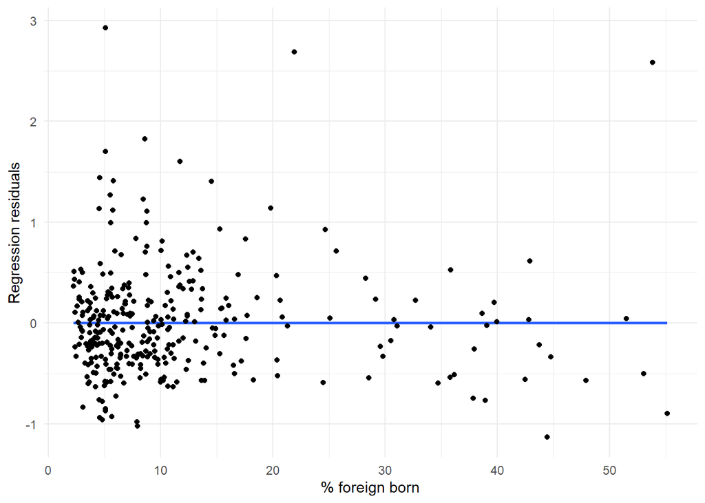

# Merging data

A big part of applied data analysis involves combining different bit of data. For that you need `merge` or `join` commands. Here is an example where we add more area level variables to our foreigners dataset:

```r
library(dplyr)
ff_raw=read.csv("https://www.dropbox.com/s/g1w75gkw7g91zef/foreigners.csv?dl=1")




ff_more=read.csv("https://www.dropbox.com/s/gwq2wmmxr8s3v7t/foreigners_more.csv?dl=1")

names(ff_more)
```

```
##  [1] "X"         "urate2010" "urate2012" "urate2004" "urate2011" "area"
##  [7] "meanage"   "medianage" "region"    "pct_leave" "mus_sh"    "citshare"
## [13] "urbshare"
```

```r
inner=ff_raw %>% inner_join(ff_more,by="area")
inner=ff_raw %>% full_join(ff_more,by="area")

inner=ff %>% inner_join(ff_more,by="area")
full=ff %>% full_join(ff_more,by="area")
```

Dataframe `ff` has 323 observations. Dataframe `ff_more` has 348. The inner join has 323, the full join 348.

# Doing stuff by region and how to use functions

One of the variables we merged earlier includes a region variable. The following command counts the number of observations for every region.

```r
inner %>% group_by(region) %>% summarise(n())
```

```
## # A tibble: 10 x 2
##    region                   `n()`
##    <chr>                    <int>
##  1 East                        43
##  2 East Midlands               40
##  3 London                      32
##  4 North East                  10
##  5 North West                  39
##  6 South East                  64
##  7 South West                  32
##  8 Wales                       22
##  9 West Midlands               27
## 10 Yorkshire and The Humber    14
```

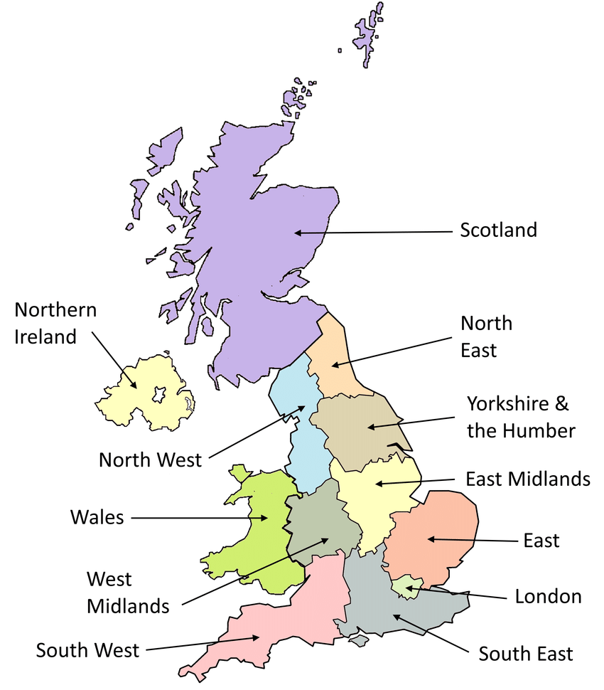

### Define the function:

```r
plotter=function(r){

  ffx=inner %>% filter(region==r)

  plot=ggplot(ffx, aes(x = b_migr11, y = crimesPc)) +
    geom_smooth(method = "lm", se = FALSE) +
    geom_point()+theme_minimal()+
    xlab("% foreign born")+ylab("Crimes per capita")+
    ggtitle(r)


  reg=(lm(crimesPc~b_migr11,ffx))
  return(list(plot,reg))
}
```

### Call the function:

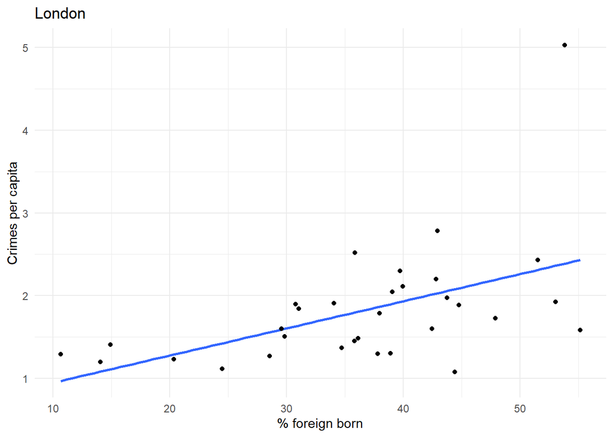

```
##
## Call:
## lm(formula = crimesPc ~ b_migr11, data = ffx)
##
## Residuals:
##      Min       1Q   Median       3Q      Max
## -1.00220 -0.35611 -0.06671  0.18426  2.64380
##
## Coefficients:
##             Estimate Std. Error t value Pr(>|t|)
## (Intercept)  0.62044    0.39045   1.589  0.12253
## b_migr11     0.03282    0.01025   3.202  0.00322 **
## ---
## Signif. codes:  0 '***' 0.001 '**' 0.01 '*' 0.05 '.' 0.1 ' ' 1
##
## Residual standard error: 0.6392 on 30 degrees of freedom
## Multiple R-squared:  0.2547, Adjusted R-squared:  0.2298
## F-statistic: 10.25 on 1 and 30 DF,  p-value: 0.003225
```

```r
p=plotter("London")
p[[1]];summary(p[[2]])
```

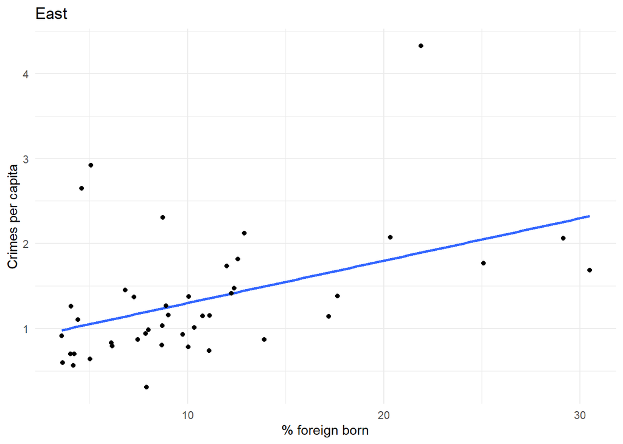

```
##
## Call:
## lm(formula = crimesPc ~ b_migr11, data = ffx)
##
## Residuals:
##     Min      1Q  Median      3Q     Max
## -0.8849 -0.3370 -0.2046  0.1440  2.4343
##
## Coefficients:
##             Estimate Std. Error t value Pr(>|t|)
## (Intercept)  0.80217    0.19602   4.092 0.000195 ***
## b_migr11     0.04982    0.01579   3.156 0.002997 **
## ---
## Signif. codes:  0 '***' 0.001 '**' 0.01 '*' 0.05 '.' 0.1 ' ' 1
##
## Residual standard error: 0.6717 on 41 degrees of freedom
## Multiple R-squared:  0.1954, Adjusted R-squared:  0.1758
## F-statistic: 9.959 on 1 and 41 DF,  p-value: 0.002997
```

```r
p=plotter("East")
p[[1]];summary(p[[2]])
```

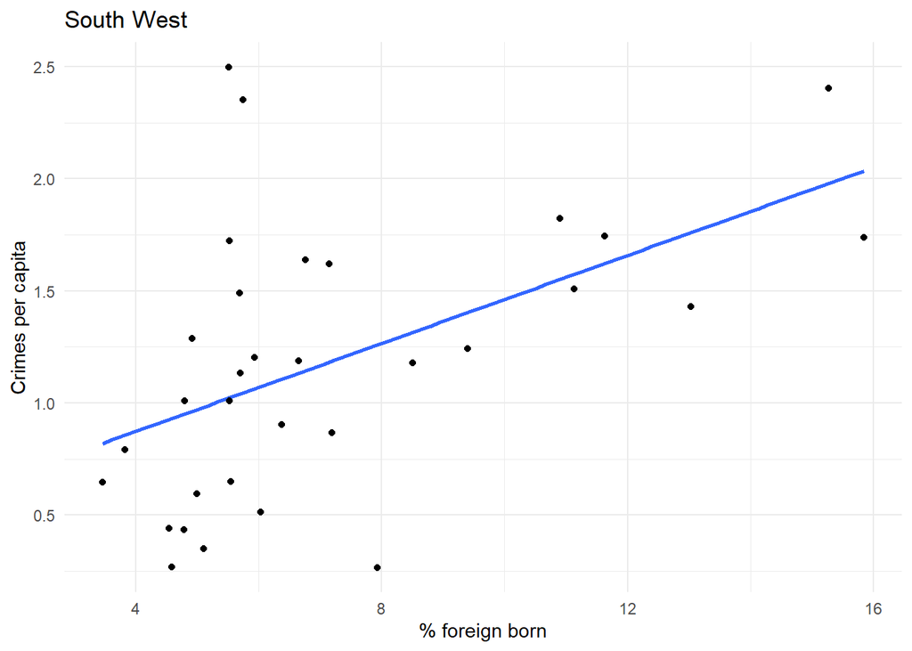

```
##
## Call:
## lm(formula = crimesPc ~ b_migr11, data = ffx)
##
## Residuals:
##      Min       1Q   Median       3Q      Max
## -0.99207 -0.34065 -0.06424  0.28628  1.47611
##
## Coefficients:
##             Estimate Std. Error t value Pr(>|t|)
## (Intercept)  0.48027    0.23850   2.014  0.05308 .
## b_migr11     0.09821    0.03040   3.231  0.00299 **
## ---
## Signif. codes:  0 '***' 0.001 '**' 0.01 '*' 0.05 '.' 0.1 ' ' 1
##
## Residual standard error: 0.5407 on 30 degrees of freedom
## Multiple R-squared:  0.2581, Adjusted R-squared:  0.2334
## F-statistic: 10.44 on 1 and 30 DF,  p-value: 0.002991
```

```r
p=plotter("South West")
p[[1]];summary(p[[2]])
```

### Or maybe doing it with a loop?

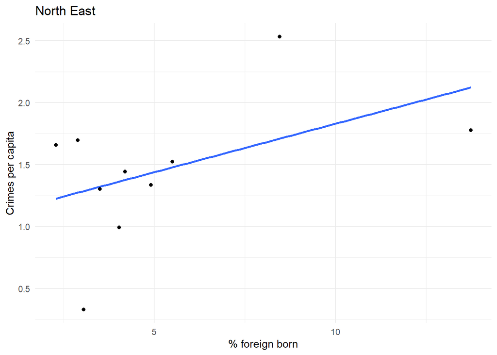

```
##
## Call:
## lm(formula = crimesPc ~ b_migr11, data = ffx)
##
## Residuals:
##      Min       1Q   Median       3Q      Max
## -0.95549 -0.28291  0.01332  0.33373  0.82333
##
## Coefficients:
##             Estimate Std. Error t value Pr(>|t|)
## (Intercept)  1.04807    0.31537   3.323   0.0105 *
## b_migr11     0.07821    0.05092   1.536   0.1631
## ---
## Signif. codes:  0 '***' 0.001 '**' 0.01 '*' 0.05 '.' 0.1 ' ' 1
##
## Residual standard error: 0.5278 on 8 degrees of freedom
## Multiple R-squared:  0.2278, Adjusted R-squared:  0.1312
## F-statistic: 2.359 on 1 and 8 DF,  p-value: 0.1631
```

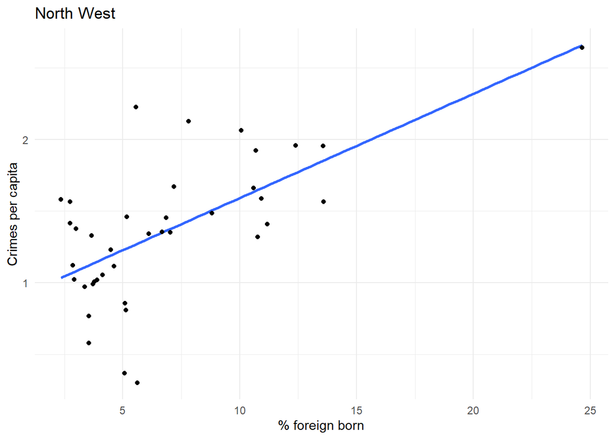

```
##
## Call:
## lm(formula = crimesPc ~ b_migr11, data = ffx)
##
## Residuals:
##      Min       1Q   Median       3Q      Max
## -0.96912 -0.14052 -0.01849  0.21011  0.95806
##
## Coefficients:
##             Estimate Std. Error t value Pr(>|t|)
## (Intercept)  0.86423    0.11455   7.544 5.40e-09 ***
## b_migr11     0.07270    0.01416   5.134 9.31e-06 ***
## ---
## Signif. codes:  0 '***' 0.001 '**' 0.01 '*' 0.05 '.' 0.1 ' ' 1
##
## Residual standard error: 0.3849 on 37 degrees of freedom
## Multiple R-squared:  0.416,  Adjusted R-squared:  0.4003
## F-statistic: 26.36 on 1 and 37 DF,  p-value: 9.308e-06
```

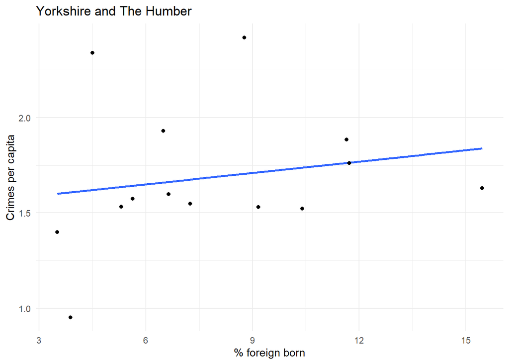

```
##
## Call:
## lm(formula = crimesPc ~ b_migr11, data = ffx)
##
## Residuals:
##      Min       1Q   Median       3Q      Max
## -0.65522 -0.19623 -0.08563  0.09058  0.71980
##
## Coefficients:
##             Estimate Std. Error t value Pr(>|t|)
## (Intercept)  1.53085    0.26058   5.875 7.54e-05 ***
## b_migr11     0.01987    0.03042   0.653    0.526
## ---
## Signif. codes:  0 '***' 0.001 '**' 0.01 '*' 0.05 '.' 0.1 ' ' 1
##
## Residual standard error: 0.3813 on 12 degrees of freedom
## Multiple R-squared:  0.03433,    Adjusted R-squared:  -0.04614
## F-statistic: 0.4266 on 1 and 12 DF,  p-value: 0.526
```

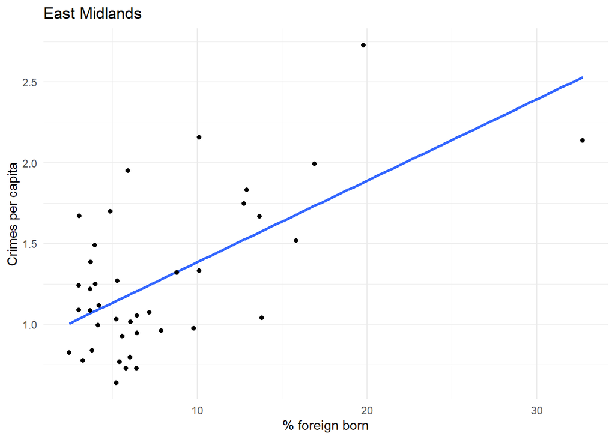

```
##
## Call:
## lm(formula = crimesPc ~ b_migr11, data = ffx)
##
## Residuals:
##      Min       1Q   Median       3Q      Max
## -0.53908 -0.26282 -0.07753  0.21221  0.85058
##
## Coefficients:
##             Estimate Std. Error t value Pr(>|t|)
## (Intercept)  0.88010    0.09965   8.832 9.57e-11 ***
## b_migr11     0.05044    0.01023   4.931 1.65e-05 ***
## ---
## Signif. codes:  0 '***' 0.001 '**' 0.01 '*' 0.05 '.' 0.1 ' ' 1
##
## Residual standard error: 0.3752 on 38 degrees of freedom
## Multiple R-squared:  0.3902, Adjusted R-squared:  0.3741
## F-statistic: 24.31 on 1 and 38 DF,  p-value: 1.649e-05
```

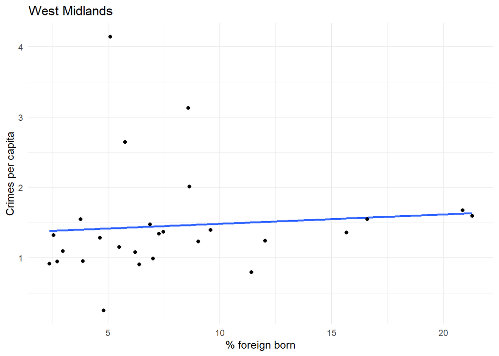

```
##
## Call:
## lm(formula = crimesPc ~ b_migr11, data = ffx)
##
## Residuals:
##      Min       1Q   Median       3Q      Max
## -1.16156 -0.39571 -0.13070  0.00326  2.72541
##
## Coefficients:
##             Estimate Std. Error t value Pr(>|t|)
## (Intercept)  1.35201    0.28400   4.761 6.93e-05 ***
## b_migr11     0.01332    0.02961   0.450    0.657
## ---
## Signif. codes:  0 '***' 0.001 '**' 0.01 '*' 0.05 '.' 0.1 ' ' 1
##
## Residual standard error: 0.7865 on 25 degrees of freedom
## Multiple R-squared:  0.008033,   Adjusted R-squared:  -0.03165
## F-statistic: 0.2025 on 1 and 25 DF,  p-value: 0.6566
```

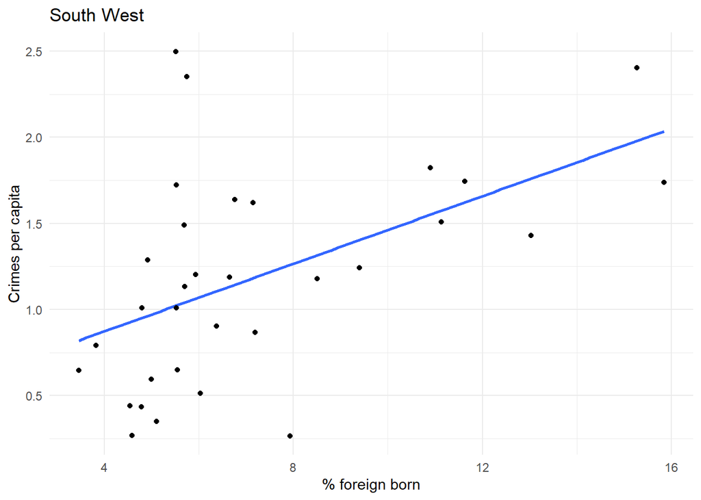

```
##
## Call:
## lm(formula = crimesPc ~ b_migr11, data = ffx)
##
## Residuals:
##      Min       1Q   Median       3Q      Max
## -0.99207 -0.34065 -0.06424  0.28628  1.47611
##
## Coefficients:
##             Estimate Std. Error t value Pr(>|t|)
## (Intercept)  0.48027    0.23850   2.014  0.05308 .
## b_migr11     0.09821    0.03040   3.231  0.00299 **
## ---
## Signif. codes:  0 '***' 0.001 '**' 0.01 '*' 0.05 '.' 0.1 ' ' 1
##
## Residual standard error: 0.5407 on 30 degrees of freedom
## Multiple R-squared:  0.2581, Adjusted R-squared:  0.2334
## F-statistic: 10.44 on 1 and 30 DF,  p-value: 0.002991
```

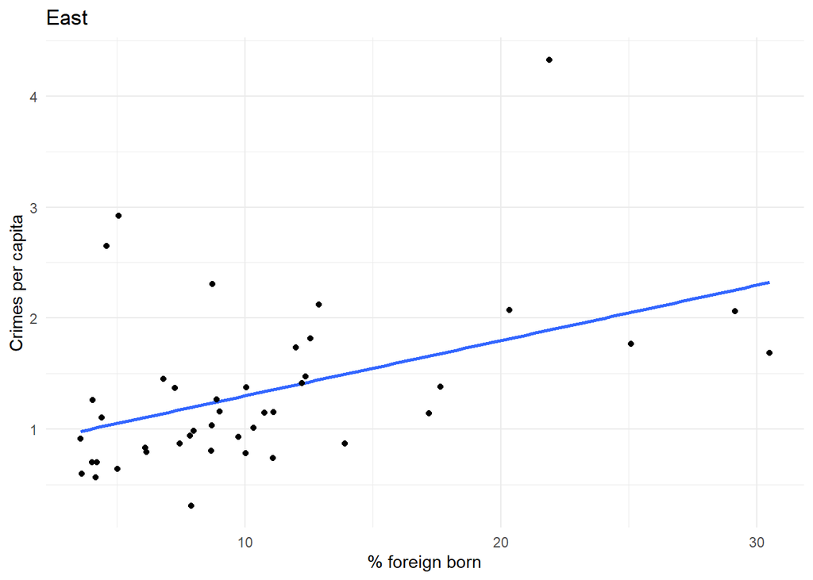

```
##
## Call:
## lm(formula = crimesPc ~ b_migr11, data = ffx)
##
## Residuals:
##     Min      1Q  Median      3Q     Max
## -0.8849 -0.3370 -0.2046  0.1440  2.4343
##
## Coefficients:
##             Estimate Std. Error t value Pr(>|t|)
## (Intercept)  0.80217    0.19602   4.092 0.000195 ***
## b_migr11     0.04982    0.01579   3.156 0.002997 **
## ---
## Signif. codes:  0 '***' 0.001 '**' 0.01 '*' 0.05 '.' 0.1 ' ' 1
##
## Residual standard error: 0.6717 on 41 degrees of freedom
## Multiple R-squared:  0.1954, Adjusted R-squared:  0.1758
## F-statistic: 9.959 on 1 and 41 DF,  p-value: 0.002997
```

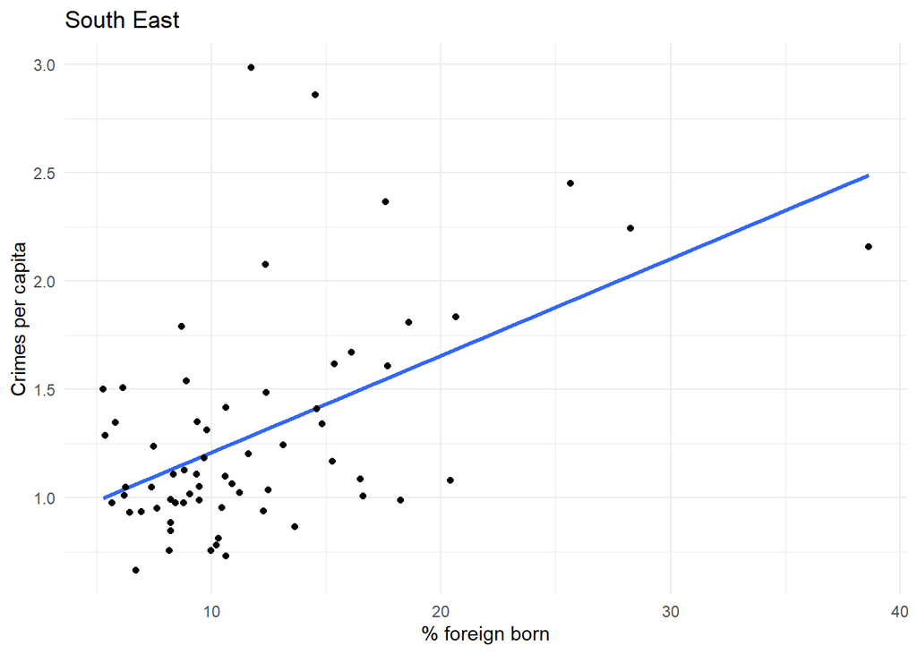

```
##
## Call:
## lm(formula = crimesPc ~ b_migr11, data = ffx)
##
## Residuals:
##      Min       1Q   Median       3Q      Max
## -0.59422 -0.27411 -0.08116  0.17012  1.70115
##
## Coefficients:
##             Estimate Std. Error t value Pr(>|t|)
## (Intercept) 0.759918   0.122436   6.207 4.96e-08 ***
## b_migr11    0.044783   0.009276   4.828 9.40e-06 ***
## ---
## Signif. codes:  0 '***' 0.001 '**' 0.01 '*' 0.05 '.' 0.1 ' ' 1
##
## Residual standard error: 0.431 on 62 degrees of freedom
## Multiple R-squared:  0.2732, Adjusted R-squared:  0.2615
## F-statistic: 23.31 on 1 and 62 DF,  p-value: 9.397e-06
```

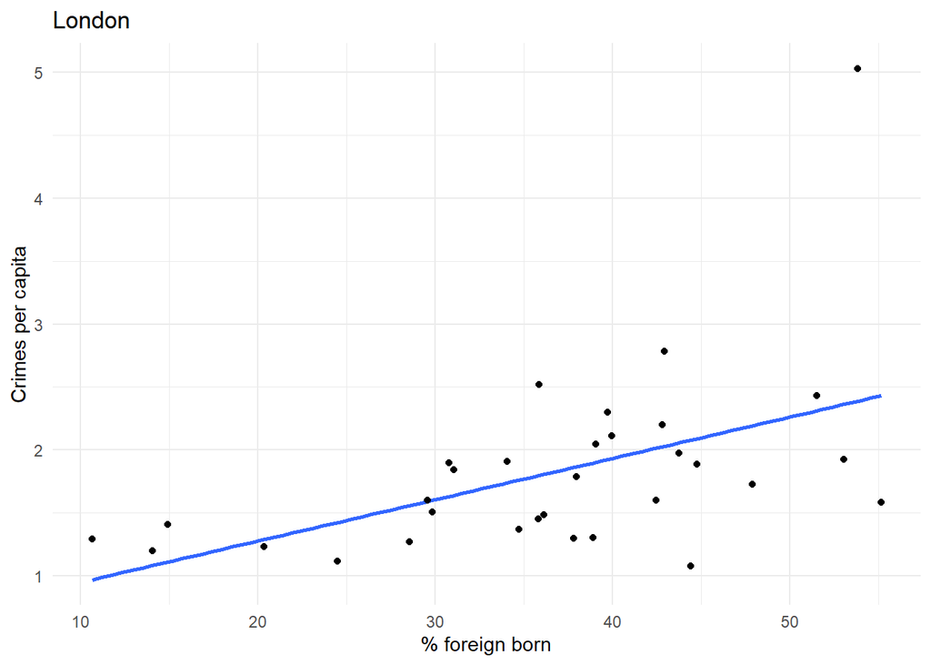

```
##
## Call:
## lm(formula = crimesPc ~ b_migr11, data = ffx)
##
## Residuals:
##      Min       1Q   Median       3Q      Max
## -1.00220 -0.35611 -0.06671  0.18426  2.64380
##
## Coefficients:
##             Estimate Std. Error t value Pr(>|t|)
## (Intercept)  0.62044    0.39045   1.589  0.12253
## b_migr11     0.03282    0.01025   3.202  0.00322 **
## ---
## Signif. codes:  0 '***' 0.001 '**' 0.01 '*' 0.05 '.' 0.1 ' ' 1
##
## Residual standard error: 0.6392 on 30 degrees of freedom
## Multiple R-squared:  0.2547, Adjusted R-squared:  0.2298
## F-statistic: 10.25 on 1 and 30 DF,  p-value: 0.003225
```

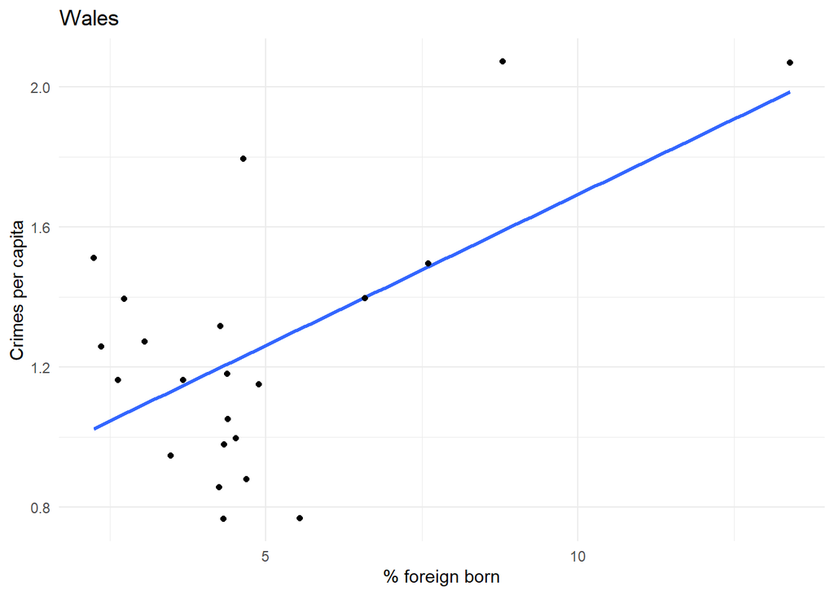

```
##
## Call:
## lm(formula = crimesPc ~ b_migr11, data = ffx)
##
## Residuals:
##      Min       1Q   Median       3Q      Max
## -0.54065 -0.21328  0.00295  0.16357  0.56448
##
## Coefficients:
##             Estimate Std. Error t value Pr(>|t|)
## (Intercept)  0.83100    0.14682    5.66 1.54e-05 ***
## b_migr11     0.08626    0.02704    3.19   0.0046 **
## ---
## Signif. codes:  0 '***' 0.001 '**' 0.01 '*' 0.05 '.' 0.1 ' ' 1
##
## Residual standard error: 0.3088 on 20 degrees of freedom
## Multiple R-squared:  0.3372, Adjusted R-squared:  0.3041
## F-statistic: 10.18 on 1 and 20 DF,  p-value: 0.0046
```

```r
regions=inner$region %>% unique()



for(rrr in regions){

  p=plotter(rrr)
  print(p[[1]])
  print(summary(p[[2]]))

}
```

[output not shown]